# LOS ANGELES DODGERS Report on Bobblehead Distribution's Effect on Fan Attendance

Prepared by  
Ali Emir Güzey 22003186  
Can Dilsiz 21702688  
Zeeshan Modi 22203965  
23.04.2023

## Introduction

This report analyzes the effect of different variables, such as month, day of week, day/night time, and distribution of bobbleheads during the game. The ultimate goal of this report is to determine whether there is a relation between booblehead distribution and attendances.

## Analysis

The following sections contain the analysis codes (in Python) and corresponding comments.

First, we import the necessary libraries.

```python
import sqlite3
import pandas as pd
import plotnine as pn
import seaborn as sns
import matplotlib.pyplot as plt
import statsmodels.api as sm
import numpy as np
from scipy import stats
from statsmodels.stats.outliers_influence import OLSInfluence
from statsmodels.stats.diagnostic import het_breuschpagan
from statsmodels.stats.anova import anova_lm
```

### 1. We connect to the database that contains the `events` table using `sqlite3` library and read the information in the table into a variable.

```python
con = sqlite3.connect('dodgers.sqlite')
events = pd.read_sql_query("SELECT * FROM events", con)
```

### 2. The table and barplot below summarize the number of games played on each weekday and month.

```python
# Convert day_of_week and month columns to factors with specified levels
events['day_of_week'] = pd.Categorical(events['day_of_week'],
                                       categories=["Monday",
                                                   "Tuesday",
                                                   "Wednesday",
                                                   "Thursday",
                                                   "Friday",
                                                   "Saturday",
                                                   "Sunday"],
                                       ordered=True)

events['month'] = pd.Categorical(events['month'],
                                 categories=["APR", "MAY", "JUN", "JUL",
                                             "AUG", "SEP", "OCT"],
                                 ordered=True)

# Convert temperature from Fahrenheit to Celsius
events['temp'] = (events['temp'] - 32) * 5/9

# Count the number of games for each combination of day_of_week and month,
# and pivot the results to create a table with months as rows and weekdays as columns
games_per_weekday_and_month = events.groupby(['day_of_week', 'month']).size().reset_index(name='count')
games_per_weekday_and_month = games_per_weekday_and_month.pivot(index='month', columns='day_of_week', values='count')

# Print the results as a table
games_per_weekday_and_month.columns.name = None
games_per_weekday_and_month.index.name = 'Month'

games_per_weekday_and_month.style.set_caption("Matches per weekday and month")
```

Matches per weekday and month

| Month | Monday | Tuesday | Wednesday | Thursday | Friday | Saturday | Sunday |
| --- | --- | --- | --- | --- | --- | --- | --- |
| APR | 1 | 2 | 2 | 1 | 2 | 2 | 2 |
| MAY | 3 | 3 | 2 | 1 | 3 | 3 | 3 |
| JUN | 1 | 1 | 1 | 1 | 2 | 2 | 1 |
| JUL | 3 | 3 | 2 | 0 | 1 | 1 | 2 |
| AUG | 2 | 2 | 3 | 1 | 3 | 2 | 2 |
| SEP | 1 | 1 | 1 | 1 | 2 | 3 | 3 |
| OCT | 1 | 1 | 1 | 0 | 0 | 0 | 0 |

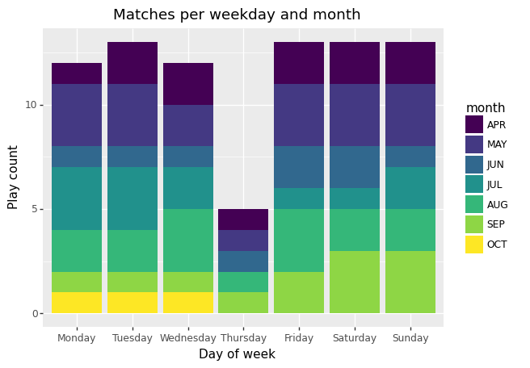

```python
print((pn.ggplot(events, pn.aes(x='day_of_week', fill='month')) +
    pn.geom_bar() +
    pn.xlab('Day of week') +
    pn.ylab('Play count') +
    pn.ggtitle('Matches per weekday and month')))
```

Below is a heatmap that shows the match attendance by day of week and month.

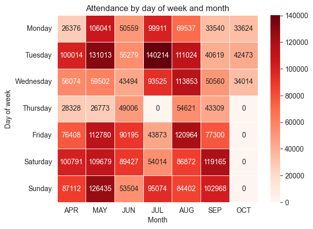

```python
# create a contingency table using crosstab function
table = pd.crosstab(events['day_of_week'], events['month'],
                    values=events['attend'], aggfunc='sum')

# create the heatmap using seaborn
sns.heatmap(table, cmap='Reds', annot=True, fmt='.0f', linewidths=.5)

# add title and axis labels
plt.title('Attendance by day of week and month')
plt.xlabel('Month')
plt.ylabel('Day of week')

# show the plot
plt.show()
```

Below scatterplots show the average and total attendances by weekday, month, and Day/Night.

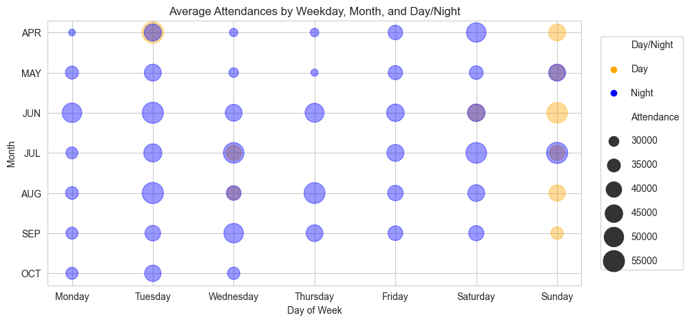

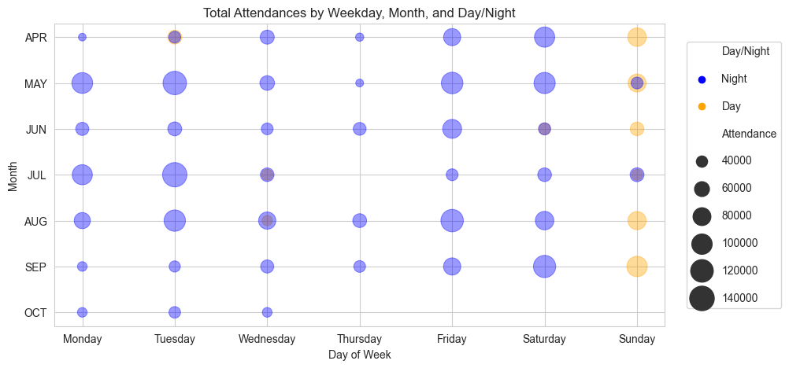

```python
# Group the data by day of week and month
grouped = events.groupby(['day_of_week', 'month', 'day_night']).mean(numeric_only=True).reset_index()
grouped = grouped.rename(columns={'day_night': 'Day/Night', 'attend': 'Attendance'})

# Create the scatterplot using Seaborn and Matplotlib
plt.figure(figsize=(10, 5))
sns.scatterplot(x='day_of_week', y='month', hue='Day/Night', size='Attendance', sizes=(50, 500),
                data=grouped, alpha=0.4, edgecolor=None,
                legend='brief', palette={'Day':'orange', 'Night':'blue'})
plt.xlabel('Day of Week')
plt.ylabel('Month')
plt.title('Average Attendances by Weekday, Month, and Day/Night')
plt.legend(loc='center right', bbox_to_anchor=(1.2, 0.5), labelspacing=1.5)
plt.show()

grouped = events.groupby(['day_of_week', 'month', 'day_night']).agg({'attend': 'sum'}).reset_index()
grouped = grouped.rename(columns={'day_night': 'Day/Night', 'attend': 'Attendance'})
grouped = grouped[grouped['Attendance'] != 0]

# Create the scatterplot using Seaborn and Matplotlib
plt.figure(figsize=(10, 5))
sns.scatterplot(x='day_of_week', y='month', hue='Day/Night', size='Attendance', sizes=(50, 500),
                data=grouped, alpha=0.4, edgecolor=None,
                legend='brief', palette={'Day':'orange', 'Night':'blue'})
plt.xlabel('Day of Week')
plt.ylabel('Month')
plt.title('Total Attendances by Weekday, Month, and Day/Night')
plt.legend(loc='center right', bbox_to_anchor=(1.2, 0.5), labelspacing=1.5)
plt.show()
```

### 3. Check the orders of the levels of the `day_of_week` and `month` factors. If necessary, put them in the logical order.

*This part is already done in the first code cell*

### 4. The following table shows how many times bobblehead promotions were run on each week day.

```python
# Create a pivot table
weekday_summary = pd.pivot_table(events,
                                 values='bobblehead',
                                 index='day_of_week',
                                 aggfunc=['count', lambda x: sum(x == 'YES')])

# Rename columns
weekday_summary.columns = ['Total Games', 'Bobblehead Promotions']
weekday_summary.index.name = 'Day of week'

# Sort by day of the week
weekday_summary = weekday_summary.sort_index()

# Print the summary
weekday_summary.style.set_caption('Bobblehead promotions run vs total games each weekday')
```

Bobblehead promotions run vs total games each weekday

| Day of week | Total Games | Bobblehead Promotions |
| --- | --- | --- |
| Monday | 12 | 0 |
| Tuesday | 13 | 6 |
| Wednesday | 12 | 0 |
| Thursday | 5 | 2 |
| Friday | 13 | 0 |
| Saturday | 13 | 2 |
| Sunday | 13 | 1 |

### 5. The following boxplot shows the distribution of attendance across weekdays.

Although a boxplot does not show the average for each day explicitly, it is visible that the games on tuesday have significantly higher attendances compared to other days

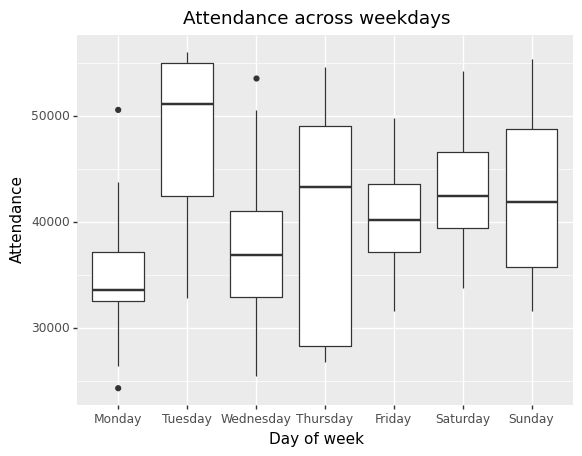

```python
print((pn.ggplot(events, pn.aes(x='day_of_week', y='attend')) +
       pn.geom_boxplot() +
       pn.xlab('Day of week') +
       pn.ylab('Attendance') +
       pn.ggtitle('Attendance across weekdays')))
```

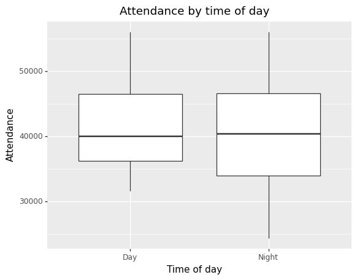

```python
print((pn.ggplot(events, pn.aes(x='day_night', y='attend'))
 + pn.geom_boxplot()
 + pn.xlab('Time of day')
 + pn.ylab('Attendance')
 + pn.ggtitle('Attendance by time of day')
))
```

```python
day_attend = events.loc[events['day_night'] == 'Day', 'attend']
night_attend = events.loc[events['day_night'] == 'Night', 'attend']
stats.ttest_ind(day_attend, night_attend)
```

```
Ttest_indResult(statistic=0.3873945937448441, pvalue=0.6995058414022302)
```

Since p-value is large (greater than 0.05), we cannot reject null, which means there is no statistical difference between average attendance of games played in day and night.

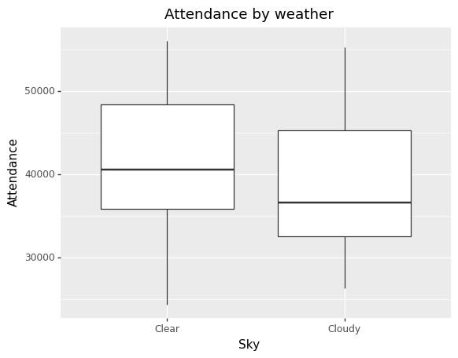

```python
print((pn.ggplot(events, pn.aes(x='skies', y='attend'))
 + pn.geom_boxplot()
 + pn.xlab('Sky')
 + pn.ylab('Attendance')
 + pn.ggtitle('Attendance by weather')
))
```

```python
clear_attend = events.loc[events['skies'] == 'Clear', 'attend']
cloudy_attend = events.loc[events['skies'] == 'Cloudy', 'attend']
stats.ttest_ind(clear_attend, cloudy_attend)
```

```
Ttest_indResult(statistic=1.3573489468590318, pvalue=0.17853549139588926)
```

By taking account of p-values, we do not see a statisticall significant difference between the average attendance of the games played under clear and cloudy skies.

### 7. Below plots show attendance by temperature and day of week to investigate if there is an association between them.

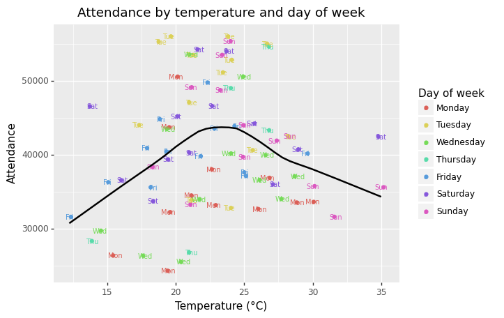

```python
print(pn.ggplot(events, pn.aes(x='temp', y='attend')) + \
    pn.geom_jitter(pn.aes(color='day_of_week')) + \
    pn.geom_text(pn.aes(x='temp', y='attend', label=events['day_of_week'].str[:3], color='day_of_week'), size=7) + \
    pn.geom_smooth(se=False) + \
    pn.xlab('Temperature (°C)') + \
    pn.ylab('Attendance') + \
    pn.labs(color='Day of week') + \
    pn.ggtitle('Attendance by temperature and day of week')+ \
    pn.scale_color_discrete())
```

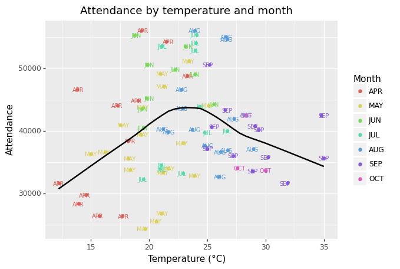

```python
print(pn.ggplot(events, pn.aes(x='temp', y='attend')) + \
    pn.geom_jitter(pn.aes(color='month')) + \
    pn.geom_text(pn.aes(x='temp', y='attend', label=events['month'], color='month'), size=7) + \
    pn.geom_smooth(se=False) + \
    pn.xlab('Temperature (°C)') + \
    pn.ylab('Attendance') + \
    pn.labs(color='Month') + \
    pn.ggtitle('Attendance by temperature and month') + \
    pn.scale_color_discrete())
```

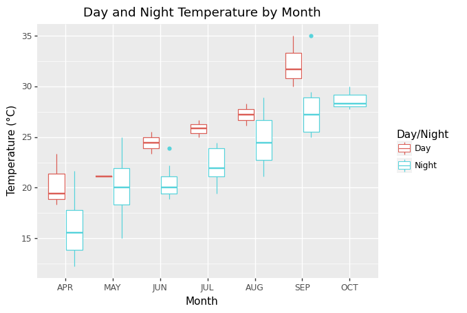

```python
print((pn.ggplot(events, pn.aes(x='month', y='temp', color='day_night'))
 + pn.geom_boxplot()
 + pn.xlab('Month')
 + pn.ylab('Temperature (°C)')
 + pn.labs(color='Day/Night')
 + pn.ggtitle('Day and Night Temperature by Month')
))
```

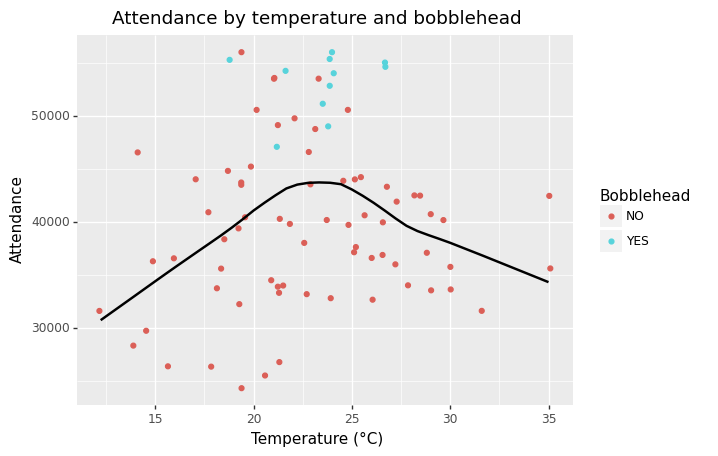

```python
print(pn.ggplot(events, pn.aes(x='temp', y='attend')) + \
    pn.geom_jitter(pn.aes(color='bobblehead')) + \
    pn.geom_smooth(se=False) + \
    pn.xlab('Temperature (°C)') + \
    pn.ylab('Attendance') + \
    pn.labs(color='Bobblehead') + \
    pn.ggtitle('Attendance by temperature and bobblehead') + \
    pn.scale_color_discrete())
```

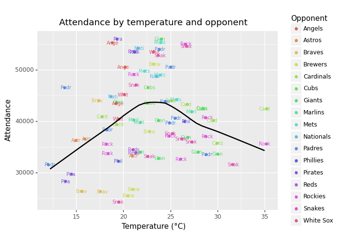

```python
print(pn.ggplot(events, pn.aes(x='temp', y='attend')) + \
    pn.geom_text(pn.aes(x='temp', y='attend', label=events['opponent'].str[:4], color='opponent'), size=7) + \
    pn.geom_jitter(pn.aes(color='opponent')) + \
    pn.geom_smooth(se=False) + \
    pn.xlab('Temperature (°C)') + \
    pn.ylab('Attendance') + \
    pn.labs(color='Opponent') + \
    pn.ggtitle('Attendance by temperature and opponent') + \
    pn.scale_color_discrete())
```

```python
lmod0 = sm.formula.ols(formula='attend ~ temp', data=events).fit()
print(lmod0.summary())
```

```
                            OLS Regression Results
==============================================================================
Dep. Variable:                 attend   R-squared:                       0.010
Model:                            OLS   Adj. R-squared:                 -0.003
Method:                 Least Squares   F-statistic:                    0.7812
Date:                Sun, 23 Apr 2023   Prob (F-statistic):              0.379
Time:                        17:04:06   Log-Likelihood:                -844.95
No. Observations:                  81   AIC:                             1694.
Df Residuals:                      79   BIC:                             1699.
Df Model:                           1
Covariance Type:            nonrobust
==============================================================================
                 coef    std err          t      P>|t|      [0.025      0.975]
------------------------------------------------------------------------------
Intercept   3.698e+04   4687.663      7.888      0.000    2.76e+04    4.63e+04
temp         177.6878    201.043      0.884      0.379    -222.478     577.853
==============================================================================
Omnibus:                        6.469   Durbin-Watson:                   1.980
Prob(Omnibus):                  0.039   Jarque-Bera (JB):                3.077
Skew:                           0.205   Prob(JB):                        0.215
Kurtosis:                       2.138   Cond. No.                         119.
==============================================================================

Notes:
[1] Standard Errors assume that the covariance matrix of the errors is correctly specified.
```

Since p-value is large in this case, We conclude that the null is consistent with the data.

Below plots repressents the diagnostic plots for lmod0.

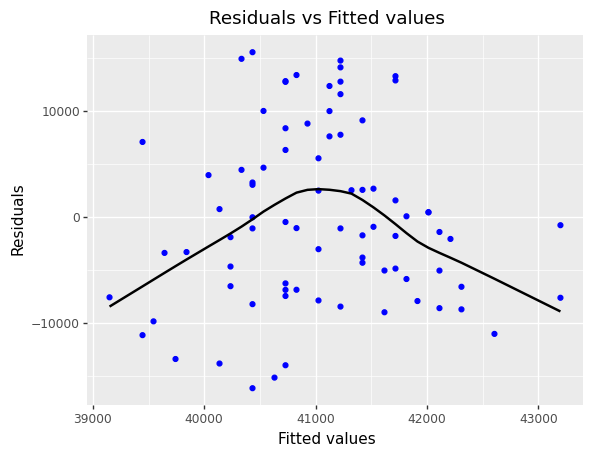

```python
df = pd.DataFrame({'fitted': lmod0.fittedvalues, 'residuals': lmod0.resid})
print(pn.ggplot(df, pn.aes(x='fitted', y='residuals')) + \
    pn.geom_point(color='blue') + \
    pn.geom_smooth(se=False) + \
    pn.xlab('Fitted values') + \
    pn.ylab('Residuals') + \
    pn.ggtitle('Residuals vs Fitted values'))
```

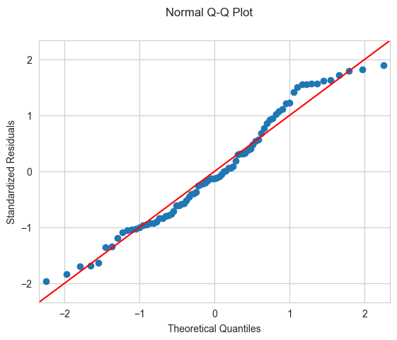

```python
fig = sm.qqplot(lmod0.resid, stats.norm, fit=True, line='45')
fig.suptitle('Normal Q-Q Plot')
fig.axes[0].set_xlabel('Theoretical Quantiles')
fig.axes[0].set_ylabel('Standardized Residuals')

plt.show()
```

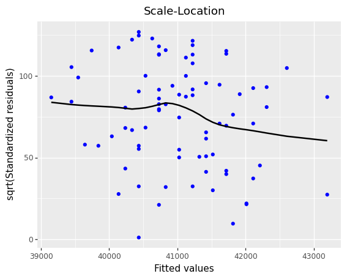

```python
df = pd.DataFrame({'fitted': lmod0.fittedvalues, 'sqrt_abs_residuals': abs(lmod0.resid)**0.5})
print(pn.ggplot(df, pn.aes(x='fitted', y='sqrt_abs_residuals')) + \
    pn.geom_point(color='blue') + \
    pn.geom_smooth(se=False) + \
    pn.xlab('Fitted values') + \
    pn.ylab('sqrt(Standardized residuals)') + \
    pn.ggtitle('Scale-Location'))
```

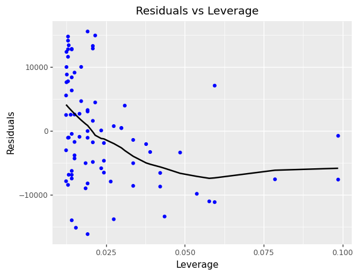

```python
df = pd.DataFrame({'residuals': lmod0.resid, 'leverage': OLSInfluence(lmod0).hat_matrix_diag})
print(pn.ggplot(df, pn.aes(x='leverage', y='residuals')) + \
    pn.geom_point(color='blue') + \
    pn.geom_smooth(se=False) + \
    pn.xlab('Leverage') + \
    pn.ylab('Residuals') + \
    pn.ggtitle('Residuals vs Leverage'))
```

```python
lmod01 = sm.formula.ols(formula='attend ~ temp + np.maximum(0, temp - 24)', data=events).fit()
print(lmod01.summary())
```

```
                            OLS Regression Results
==============================================================================
Dep. Variable:                 attend   R-squared:                       0.165
Model:                            OLS   Adj. R-squared:                  0.143
Method:                 Least Squares   F-statistic:                     7.696
Date:                Sun, 23 Apr 2023   Prob (F-statistic):           0.000890
Time:                        17:04:08   Log-Likelihood:                -838.06
No. Observations:                  81   AIC:                             1682.
Df Residuals:                      78   BIC:                             1689.
Df Model:                           2
Covariance Type:            nonrobust
============================================================================================
                               coef    std err          t      P>|t|      [0.025      0.975]
--------------------------------------------------------------------------------------------
Intercept                 1.733e+04   6740.516      2.571      0.012    3910.850    3.07e+04
temp                      1172.7483    320.803      3.656      0.000     534.078    1811.418
np.maximum(0, temp - 24) -2351.0332    617.870     -3.805      0.000   -3581.117   -1120.949
==============================================================================
Omnibus:                        1.803   Durbin-Watson:                   2.171
Prob(Omnibus):                  0.406   Jarque-Bera (JB):                1.330
Skew:                           0.063   Prob(JB):                        0.514
Kurtosis:                       2.385   Cond. No.                         185.
==============================================================================

Notes:
[1] Standard Errors assume that the covariance matrix of the errors is correctly specified.
```

Here F-stat p-value is small (small if < 0.05). Therefore we reject the null (null is equivalent to saying no relation between attendance and predictors in the right). So find that temp is a useful predictor.

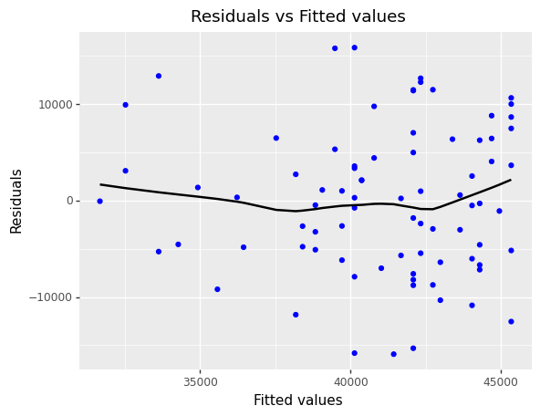

```python
df = pd.DataFrame({'fitted': lmod01.fittedvalues, 'residuals': lmod01.resid})
print(pn.ggplot(df, pn.aes(x='fitted', y='residuals')) + \
    pn.geom_point(color='blue') + \
    pn.geom_smooth(se=False) + \
    pn.xlab('Fitted values') + \
    pn.ylab('Residuals') + \
    pn.ggtitle('Residuals vs Fitted values'))
```

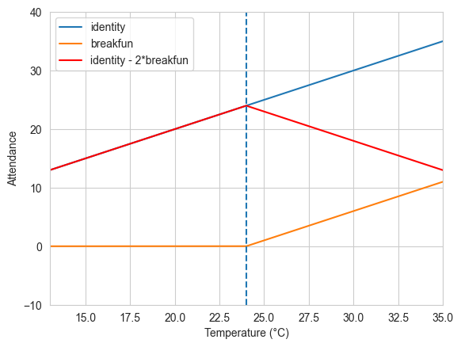

```python
def identity(x):
    return x

def breakfun(x):
    return np.maximum(x-24,0)

x = np.linspace(13, 35, 1000)

plt.plot(x, identity(x), label='identity')
plt.plot(x, breakfun(x), label='breakfun')
plt.plot(x, identity(x) - 2 * breakfun(x), label='identity - 2*breakfun', color='red')

plt.xlim(13, 35)
plt.ylim(-10, 40)
plt.xlabel('Temperature (°C)')
plt.ylabel('Attendance')
plt.vlines(x=24, ymin=-10, ymax=40, linestyles='dashed')
plt.legend()
plt.show()
```

**20 MARCH LINEAR REGRESSION MODEL:**

```python
lmod1 = sm.formula.ols(formula='attend ~ month + day_of_week + bobblehead', data=events).fit()
print(lmod1.summary())
```

```
                            OLS Regression Results
==============================================================================
Dep. Variable:                 attend   R-squared:                       0.544
Model:                            OLS   Adj. R-squared:                  0.456
Method:                 Least Squares   F-statistic:                     6.158
Date:                Sun, 23 Apr 2023   Prob (F-statistic):           2.08e-07
Time:                        17:04:08   Log-Likelihood:                -813.52
No. Observations:                  81   AIC:                             1655.
Df Residuals:                      67   BIC:                             1689.
Df Model:                          13
Covariance Type:            nonrobust
============================================================================================
                               coef    std err          t      P>|t|      [0.025      0.975]
--------------------------------------------------------------------------------------------
Intercept                 3.391e+04   2521.806     13.446      0.000    2.89e+04    3.89e+04
month[T.MAY]             -2385.6248   2291.216     -1.041      0.302   -6958.912    2187.662
month[T.JUN]              7163.2336   2732.721      2.621      0.011    1708.699    1.26e+04
month[T.JUL]              2849.8281   2578.600      1.105      0.273   -2297.079    7996.735
month[T.AUG]              2377.9243   2402.915      0.990      0.326   -2418.314    7174.162
month[T.SEP]                29.0302   2521.249      0.012      0.991   -5003.404    5061.464
month[T.OCT]              -662.6677   4046.452     -0.164      0.870   -8739.419    7414.083
day_of_week[T.Tuesday]    7911.4936   2702.208      2.928      0.005    2517.864    1.33e+04
day_of_week[T.Wednesday]  2460.0232   2514.029      0.979      0.331   -2558.000    7478.046
day_of_week[T.Thursday]    775.3638   3486.154      0.222      0.825   -6183.029    7733.757
day_of_week[T.Friday]     4883.8183   2504.653      1.950      0.055    -115.490    9883.127
day_of_week[T.Saturday]   6372.0558   2552.084      2.497      0.015    1278.075    1.15e+04
day_of_week[T.Sunday]     6724.0027   2506.721      2.682      0.009    1720.567    1.17e+04
bobblehead[T.YES]         1.071e+04   2419.520      4.429      0.000    5885.521    1.55e+04
==============================================================================
Omnibus:                        6.343   Durbin-Watson:                   2.130
Prob(Omnibus):                  0.042   Jarque-Bera (JB):                5.908
Skew:                           0.654   Prob(JB):                       0.0521
Kurtosis:                       3.205   Cond. No.                         9.76
==============================================================================

Notes:
[1] Standard Errors assume that the covariance matrix of the errors is correctly specified.
```

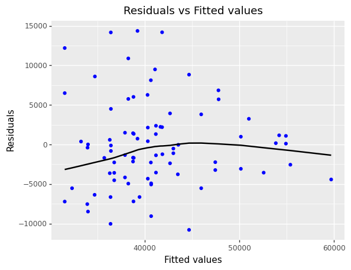

```python
df = pd.DataFrame({'fitted': lmod1.fittedvalues, 'residuals': lmod1.resid})
print(pn.ggplot(df, pn.aes(x='fitted', y='residuals')) + \
    pn.geom_point(color='blue') + \
    pn.geom_smooth(se=False) + \
    pn.xlab('Fitted values') + \
    pn.ylab('Residuals') + \
    pn.ggtitle('Residuals vs Fitted values'))
```

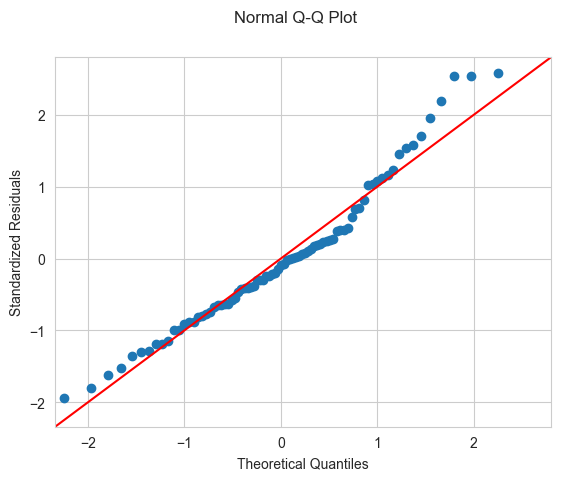

```python
fig = sm.qqplot(lmod1.resid, stats.norm, fit=True, line='45')
fig.suptitle('Normal Q-Q Plot')
fig.axes[0].set_xlabel('Theoretical Quantiles')
fig.axes[0].set_ylabel('Standardized Residuals')

plt.show()
```

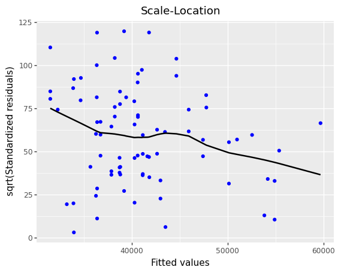

```python
df = pd.DataFrame({'fitted': lmod1.fittedvalues, 'sqrt_abs_residuals': abs(lmod1.resid)**0.5})
print(pn.ggplot(df, pn.aes(x='fitted', y='sqrt_abs_residuals')) + \
    pn.geom_point(color='blue') + \
    pn.geom_smooth(se=False) + \
    pn.xlab('Fitted values') + \
    pn.ylab('sqrt(Standardized residuals)') + \
    pn.ggtitle('Scale-Location'))
```

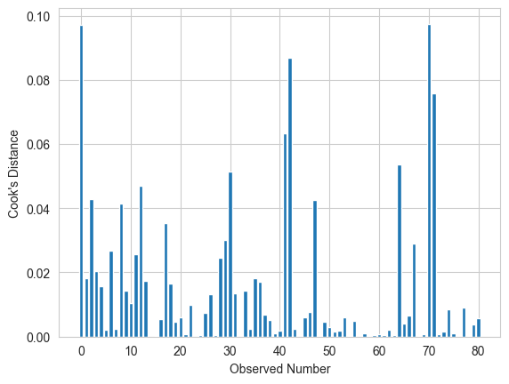

```python
# Calculate Cook's distance
influence = lmod1.get_influence()
(cooks_d, _) = influence.cooks_distance

# Plot Cook's distance against observed numbers
plt.bar(events.index, cooks_d)
plt.xlabel("Observed Number")
plt.ylabel("Cook's Distance")
plt.show()
```

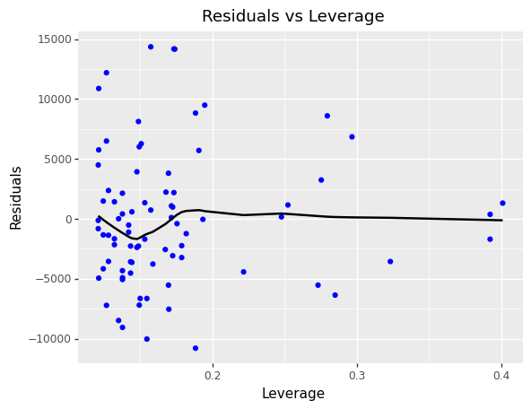

```python
df = pd.DataFrame({'residuals': lmod1.resid, 'leverage': OLSInfluence(lmod1).hat_matrix_diag})
print(pn.ggplot(df, pn.aes(x='leverage', y='residuals')) + \
    pn.geom_point(color='blue') + \
    pn.geom_smooth(se=False) + \
    pn.xlab('Leverage') + \
    pn.ylab('Residuals') + \
    pn.ggtitle('Residuals vs Leverage'))
```

```python
_, pval, _, _ = het_breuschpagan(lmod1.resid, lmod1.model.exog)
print("Breusch-Pagan test p-value: ", pval)

# used similar test for python via giving the o -value
```

```
Breusch-Pagan test p-value:  0.06024144297789468
```

```python
# extract standardized residuals from lmod1
std_resid = lmod1.get_influence().resid_studentized

# perform Shapiro-Wilk normality test
stat, p_value = stats.shapiro(std_resid)
print("Shapiro-Wilk test statistic (W):", stat)
print("p-value:", p_value)
```

```
Shapiro-Wilk test statistic (W): 0.9619021415710449
p-value: 0.01658245548605919
```

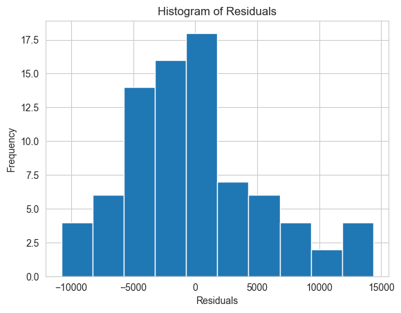

```python
# Extract residuals and fitted values
resid = lmod1.resid
fitted = lmod1.fittedvalues

# Histogram of residuals
plt.hist(resid)
plt.xlabel("Residuals")
plt.ylabel("Frequency")
plt.title("Histogram of Residuals")
plt.show()
```

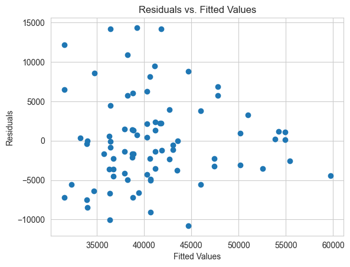

```python
# Residuals vs. fitted values
plt.scatter(fitted, resid)
plt.xlabel("Fitted Values")
plt.ylabel("Residuals")
plt.title("Residuals vs. Fitted Values")
plt.show()
```

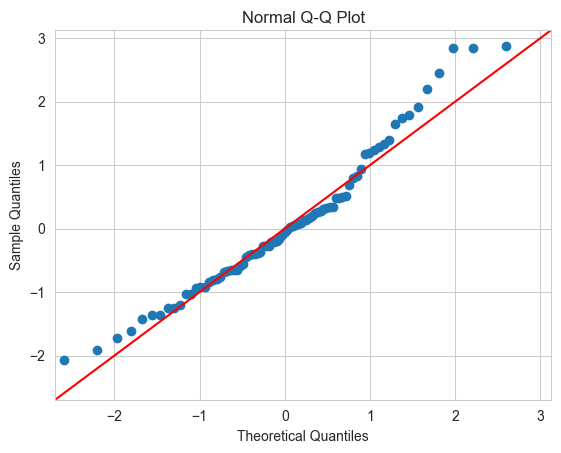

```python
# Q-Q plot
fig = sm.qqplot(resid, stats.t, fit=True, line='45')
plt.title("Normal Q-Q Plot")
plt.show()
```

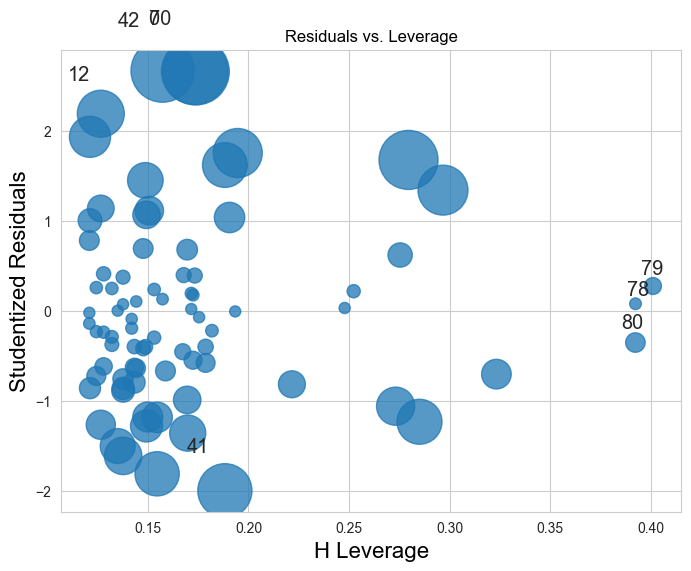

```python
# Residuals vs. leverage
fig, ax = plt.subplots(figsize=(8,6))
sm.graphics.influence_plot(lmod1, ax=ax)
plt.title("Residuals vs. Leverage")
plt.show()
```

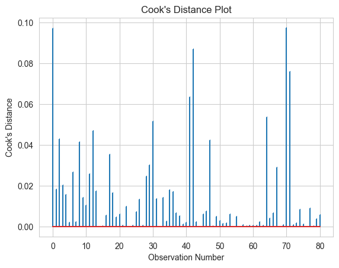

```python
# Cook's distance plot
infl = lmod1.get_influence()
(c, p) = infl.cooks_distance
plt.stem(np.arange(len(c)), c, markerfmt=",")
plt.xlabel("Observation Number")
plt.ylabel("Cook's Distance")
plt.title("Cook's Distance Plot")
plt.show()
```

```python
# fit the linear regression model
lmod2 = sm.formula.ols('attend ~ month * day_of_week + bobblehead', data=events).fit()
print(lmod2.summary())
```

```
                            OLS Regression Results
==============================================================================
Dep. Variable:                 attend   R-squared:                       0.803
Model:                            OLS   Adj. R-squared:                  0.563
Method:                 Least Squares   F-statistic:                     3.343
Date:                Sun, 23 Apr 2023   Prob (F-statistic):           0.000164
Time:                        17:04:11   Log-Likelihood:                -779.48
No. Observations:                  81   AIC:                             1649.
Df Residuals:                      36   BIC:                             1757.
Df Model:                          44
Covariance Type:            nonrobust
=========================================================================================================
                                            coef    std err          t      P>|t|      [0.025      0.975]
---------------------------------------------------------------------------------------------------------
Intercept                              2.638e+04   5484.564      4.809      0.000    1.53e+04    3.75e+04
month[T.MAY]                           8971.0000   6333.029      1.417      0.165   -3872.978    2.18e+04
month[T.JUN]                           2.418e+04   7756.345      3.118      0.004    8452.404    3.99e+04
month[T.JUL]                           6927.6667   6333.029      1.094      0.281   -5916.311    1.98e+04
month[T.AUG]                           8392.5000   6717.192      1.249      0.220   -5230.596     2.2e+04
month[T.SEP]                           7164.0000   7756.345      0.924      0.362   -8566.596    2.29e+04
month[T.OCT]                           7248.0000   7756.345      0.934      0.356   -8482.596     2.3e+04
day_of_week[T.Tuesday]                 2.363e+04   6717.192      3.518      0.001       1e+04    3.73e+04
day_of_week[T.Wednesday]               1661.0000   6717.192      0.247      0.806    -1.2e+04    1.53e+04
day_of_week[T.Thursday]                1952.0000   7756.345      0.252      0.803   -1.38e+04    1.77e+04
day_of_week[T.Friday]                  1.183e+04   6717.192      1.761      0.087   -1795.096    2.55e+04
day_of_week[T.Saturday]                1.788e+04   6952.954      2.572      0.014    3782.292     3.2e+04
day_of_week[T.Sunday]                  1.718e+04   6717.192      2.558      0.015    3556.904    3.08e+04
bobblehead[T.YES]                      1.227e+04   3590.490      3.418      0.002    4990.077    1.96e+04
month[T.MAY]:day_of_week[T.Tuesday]   -2.349e+04   8420.445     -2.789      0.008   -4.06e+04   -6410.831
month[T.JUN]:day_of_week[T.Tuesday]   -3.118e+04   1.09e+04     -2.869      0.007   -5.32e+04   -9136.029
month[T.JUL]:day_of_week[T.Tuesday]   -1.429e+04   8161.292     -1.751      0.089   -3.08e+04    2264.559
month[T.AUG]:day_of_week[T.Tuesday]   -1.516e+04   9385.772     -1.615      0.115   -3.42e+04    3875.800
month[T.SEP]:day_of_week[T.Tuesday]   -1.655e+04   1.03e+04     -1.613      0.115   -3.74e+04    4257.623
month[T.OCT]:day_of_week[T.Tuesday]   -1.478e+04   1.03e+04     -1.441      0.158   -3.56e+04    6027.623
month[T.MAY]:day_of_week[T.Wednesday] -7257.0000   8377.810     -0.866      0.392   -2.42e+04    9733.986
month[T.JUN]:day_of_week[T.Wednesday] -8726.0000   1.03e+04     -0.850      0.401   -2.95e+04    1.21e+04
month[T.JUL]:day_of_week[T.Wednesday]   1.18e+04   8377.810      1.408      0.168   -5193.153    2.88e+04
month[T.AUG]:day_of_week[T.Wednesday]  1521.5000   8377.810      0.182      0.857   -1.55e+04    1.85e+04
month[T.SEP]:day_of_week[T.Wednesday]  1.536e+04   1.03e+04      1.497      0.143   -5450.623    3.62e+04
month[T.OCT]:day_of_week[T.Wednesday] -1271.0000   1.03e+04     -0.124      0.902   -2.21e+04    1.95e+04
```

[output cut: 20 more lines]

```
month[T.JUL]:day_of_week[T.Sunday]    -9082.6310   8567.999     -1.060      0.296   -2.65e+04    8294.076
month[T.AUG]:day_of_week[T.Sunday]    -9747.5000   8671.857     -1.124      0.268   -2.73e+04    7839.841
month[T.SEP]:day_of_week[T.Sunday]     -1.64e+04   9231.897     -1.776      0.084   -3.51e+04    2325.821
month[T.OCT]:day_of_week[T.Sunday]             0          0        nan        nan           0           0
==============================================================================
Omnibus:                        4.901   Durbin-Watson:                   2.455
Prob(Omnibus):                  0.086   Jarque-Bera (JB):                6.393
Skew:                          -0.118   Prob(JB):                       0.0409
Kurtosis:                       4.356   Cond. No.                     3.02e+16
==============================================================================

Notes:
[1] Standard Errors assume that the covariance matrix of the errors is correctly specified.
[2] The smallest eigenvalue is 1.17e-31. This might indicate that there are
strong multicollinearity problems or that the design matrix is singular.
```

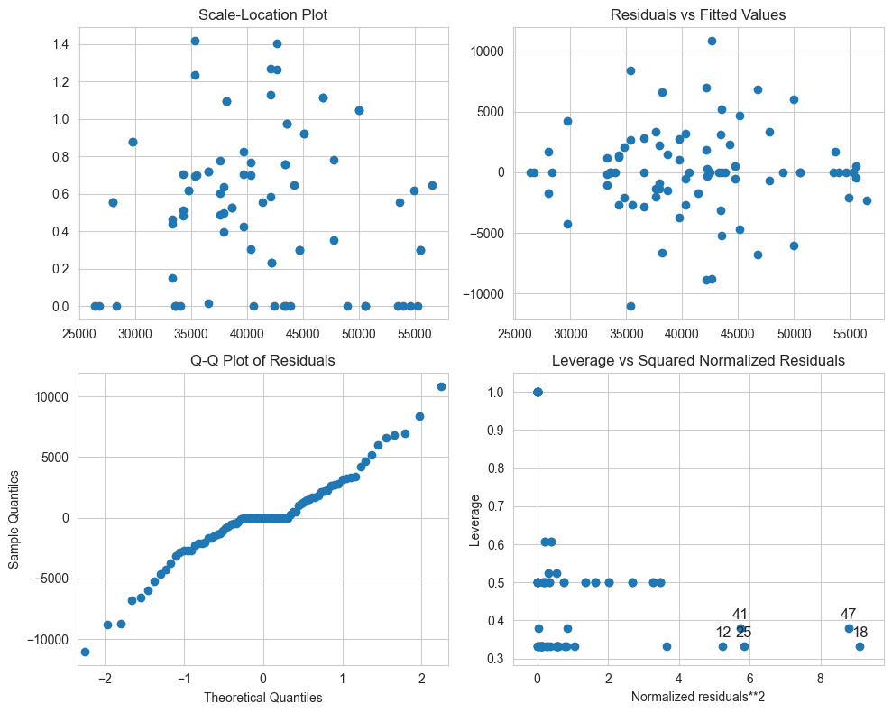

```python
# plot diagnostic plots
fig, ax = plt.subplots(2, 2, figsize=(10,8))

# Create the scale-location plot
ax[0,0].scatter(lmod2.fittedvalues, np.sqrt(abs(lmod2.resid_pearson)))

ax[0,0].set_title('Scale-Location Plot')


# plot residuals vs fitted values
ax[0,1].scatter(lmod2.fittedvalues, lmod2.resid)
ax[0,1].set_title('Residuals vs Fitted Values')

# plot Q-Q plot of residuals
sm.qqplot(lmod2.resid, ax=ax[1,0])
ax[1,0].set_title('Q-Q Plot of Residuals')

# plot leverage vs squared normalized residuals
sm.graphics.plot_leverage_resid2(lmod2, ax=ax[1,1])
ax[1,1].set_title('Leverage vs Squared Normalized Residuals')

plt.tight_layout()
plt.show()
```

```python
# Perform ANOVA to compare the two models
anova_results = anova_lm(lmod1, lmod2)
print(anova_results)
```

```
   df_resid           ssr  df_diff       ss_diff         F    Pr(>F)
0      67.0  2.509575e+09      0.0           NaN       NaN       NaN
1      36.0  1.082896e+09     31.0  1.426679e+09  1.529961  0.109612
```

```python
# Print the AIC values
print("Model 1 AIC:", lmod1.aic)
print("Model 2 AIC:", lmod2.aic)
```

```
Model 1 AIC: 1655.0313662463982
Model 2 AIC: 1648.952940989513
```

### 8. Is there any evidence for a relationship between attendance and other variables? Why or why not?

There is a relationship between attendance and other variables because when we look at the p-value of the F-statistic, it is small – therefore we reject the null hypothesis and say that there is a relationship between attendance and other variables.

### 9. Does the bobblehead promotion have a statistically significant effect on the attendance?

```python
lmod2_no_bobble = sm.formula.ols('attend ~ month*day_of_week', data=events).fit()

# Perform ANOVA test
anova_results = anova_lm(lmod2_no_bobble, lmod2)

# Print the ANOVA table
print(anova_results)
```

```
   df_resid           ssr  df_diff       ss_diff          F    Pr(>F)
0      37.0  1.434296e+09      0.0           NaN        NaN       NaN
1      36.0  1.082896e+09      1.0  3.514005e+08  11.682027  0.001582
```

Yes, because the p-value is small – therefore we reject the small model and say that bobblehead promotion has a statistically significant effect on the attendance.

```python
# Print the AIC values
print("Model 1 AIC:", lmod2_no_bobble.aic)
print("Model 2 AIC:", lmod2.aic)
```

```
Model 1 AIC: 1669.7168243669216
Model 2 AIC: 1648.952940989513
```

### 10. Do month and day of week variables help to explain the number of attendants?

Yes, because the p-value is small – therefore we reject the small model.

```python
lmod2_no_month = sm.formula.ols('attend ~ bobblehead', data=events).fit()

# Perform ANOVA test
anova_results = anova_lm(lmod2_no_month, lmod2)

# Print the ANOVA table
print(anova_results)
```

```
   df_resid           ssr  df_diff       ss_diff         F    Pr(>F)
0      79.0  3.642937e+09      0.0           NaN       NaN       NaN
1      36.0  1.082896e+09     43.0  2.560041e+09  1.979221  0.019053
```

Month is an important variable because small model’s p-value is small – therefore we reject the small model.

```python
print(lmod2.summary2().tables[1]['Coef.']['bobblehead[T.YES]'])
```

```
12271.928571428547
```

```python
conf_interval = lmod2.conf_int(alpha=0.05).loc["bobblehead[T.YES]"]

# Print the confidence interval
print("Confidence interval for bobbleheadYES:")
print(conf_interval)
```

```
Confidence interval for bobbleheadYES:
0     4990.077453
1    19553.779690
Name: bobblehead[T.YES], dtype: float64
```

```python
conf_interval = lmod2.conf_int(alpha=0.05).loc["bobblehead[T.YES]"]

# Print the confidence interval
print("Confidence interval for bobbleheadYES:")
print(conf_interval)
```

```
Confidence interval for bobbleheadYES:
0     4990.077453
1    19553.779690
Name: bobblehead[T.YES], dtype: float64
```

```python
df = pd.DataFrame({"month": ["JUN"], "day_of_week": ["Wednesday"], "bobblehead": ["YES"]})

# Use the predict() function of the fitted model to get the predicted value and prediction interval for the new observation
pred_results = lmod2.get_prediction(df).summary_frame(alpha=0.05)

# Print the predicted value and prediction interval
print("Predicted value and 90% prediction interval:")
print(pred_results[["mean", "mean_ci_lower", "mean_ci_upper"]])
```

[output not shown]

```python
df = pd.DataFrame({"month": ["JUN"], "day_of_week": ["Wednesday"], "bobblehead": ["NO"]})

# Use the predict() function of the fitted model to get the predicted value and prediction interval for the new observation
pred_results = lmod2.get_prediction(df).summary_frame(alpha=0.5)

# Print the predicted value and prediction interval
print("Predicted value and 90% prediction interval:")
print(pred_results[["mean", "mean_ci_lower", "mean_ci_upper"]])
```

[output not shown]

```python
df = pd.DataFrame({"month": ["APR"], "day_of_week": ["Sunday"], "bobblehead": ["YES"]})

# Use the predict() function of the fitted model to get the predicted value and prediction interval for the new observation
pred_results = lmod2.get_prediction(df).summary_frame(alpha=0.05)

# Print the predicted value and prediction interval
print("Predicted value and 90% prediction interval:")
print(pred_results[["mean", "mean_ci_lower", "mean_ci_upper"]])
```

[output not shown]

```python
df = pd.DataFrame({"month": ["AUG"], "day_of_week": ["Monday"], "bobblehead": ["YES"]})

# Use the predict() function of the fitted model to get the predicted value and prediction interval for the new observation
pred_results = lmod2.get_prediction(df).summary_frame(alpha=0.1)

# Print the predicted value and prediction interval
print("Predicted value and 90% prediction interval:")
print(pred_results[["mean", "mean_ci_lower", "mean_ci_upper"]])
```

```
Predicted value and 90% prediction interval:
           mean  mean_ci_lower  mean_ci_upper
0  47040.428571   38117.677083    55963.18006
```

```python
df = pd.DataFrame({"month": ["JUN"], "day_of_week": ["Wednesday"], "bobblehead": ["YES"]})

# Use the predict() function of the fitted model to get the predicted value and prediction interval for the new observation
pred_results = lmod2.get_prediction(df).summary_frame(alpha=0.05)

# Print the predicted value and prediction interval
print("Predicted value and 90% prediction interval:")
print(pred_results[["mean", "mean_ci_lower", "mean_ci_upper"]])
```

[output not shown]